# Lab 2: Cats vs Dogs

### Part (c) - 3pt

Train `large_net` with all default parameters, including with `learning_rate=0.01`. Now, set `batch_size=512`. Does the model take longer/shorter to train? Plot the training curve. Describe the effect of *increasing* the batch size.

```
Files already downloaded and verified
Files already downloaded and verified
Epoch 1: Train err: 0.48175, Train loss: 0.6929379440844059 |Validation err: 0.478, Validation loss: 0.6926823854446411
Epoch 2: Train err: 0.457625, Train loss: 0.6924103908240795 |Validation err: 0.434, Validation loss: 0.6917425096035004
Epoch 3: Train err: 0.437, Train loss: 0.6916500627994537 |Validation err: 0.4265, Validation loss: 0.690913051366806
Epoch 4: Train err: 0.433625, Train loss: 0.6908450089395046 |Validation err: 0.424, Validation loss: 0.6897871494293213
Epoch 5: Train err: 0.434, Train loss: 0.6896936111152172 |Validation err: 0.424, Validation loss: 0.6881358772516251
Epoch 6: Train err: 0.43825, Train loss: 0.6883534900844097 |Validation err: 0.4285, Validation loss: 0.6860131174325943
Epoch 7: Train err: 0.439375, Train loss: 0.6866878345608711 |Validation err: 0.426, Validation loss: 0.6836971789598465
Epoch 8: Train err: 0.43525, Train loss: 0.6849784627556801 |Validation err: 0.4115, Validation loss: 0.6814679950475693
Epoch 9: Train err: 0.42375, Train loss: 0.6832025274634361 |Validation err: 0.414, Validation loss: 0.6795949339866638
Epoch 10: Train err: 0.421, Train loss: 0.6811103448271751 |Validation err: 0.416, Validation loss: 0.6771564036607742
Epoch 11: Train err: 0.420625, Train loss: 0.6794058494269848 |Validation err: 0.4095, Validation loss: 0.6748102158308029
Epoch 12: Train err: 0.41475, Train loss: 0.6768062599003315 |Validation err: 0.4125, Validation loss: 0.6737002432346344
Epoch 13: Train err: 0.4105, Train loss: 0.674970056861639 |Validation err: 0.412, Validation loss: 0.6706106811761856
Epoch 14: Train err: 0.407375, Train loss: 0.6730919368565083 |Validation err: 0.413, Validation loss: 0.6692209243774414
Epoch 15: Train err: 0.40025, Train loss: 0.6706868708133698 |Validation err: 0.4105, Validation loss: 0.6672680974006653
Epoch 16: Train err: 0.397625, Train loss: 0.6691783033311367 |Validation err: 0.4045, Validation loss: 0.6649179607629776
Epoch 17: Train err: 0.394, Train loss: 0.667577650398016 |Validation err: 0.401, Validation loss: 0.663038358092308
Epoch 18: Train err: 0.392625, Train loss: 0.6648035235702991 |Validation err: 0.394, Validation loss: 0.6624009907245636
Epoch 19: Train err: 0.386625, Train loss: 0.6627448461949825 |Validation err: 0.3875, Validation loss: 0.6597361117601395
Epoch 20: Train err: 0.38175, Train loss: 0.6596259884536266 |Validation err: 0.4005, Validation loss: 0.6564439684152603
Epoch 21: Train err: 0.38575, Train loss: 0.6584903821349144 |Validation err: 0.388, Validation loss: 0.6586990356445312
Epoch 22: Train err: 0.378625, Train loss: 0.655131608247757 |Validation err: 0.3855, Validation loss: 0.6528825759887695
Epoch 23: Train err: 0.372125, Train loss: 0.6509063988924026 |Validation err: 0.3835, Validation loss: 0.6498387306928635
Epoch 24: Train err: 0.3765, Train loss: 0.648829746991396 |Validation err: 0.3845, Validation loss: 0.647501215338707
Epoch 25: Train err: 0.369125, Train loss: 0.6446185111999512 |Validation err: 0.382, Validation loss: 0.6473549008369446
Epoch 26: Train err: 0.372625, Train loss: 0.6428725533187389 |Validation err: 0.3745, Validation loss: 0.6426469683647156
Epoch 27: Train err: 0.359375, Train loss: 0.6372862495481968 |Validation err: 0.3765, Validation loss: 0.6397417485713959
Epoch 28: Train err: 0.354125, Train loss: 0.6338104344904423 |Validation err: 0.3705, Validation loss: 0.6404649168252945
Epoch 29: Train err: 0.354125, Train loss: 0.6311338506639004 |Validation err: 0.367, Validation loss: 0.6336435824632645
Epoch 30: Train err: 0.3525, Train loss: 0.6283648982644081 |Validation err: 0.3675, Validation loss: 0.632505863904953
Finished Training
Total time elapsed: 107.92 seconds
```

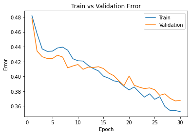

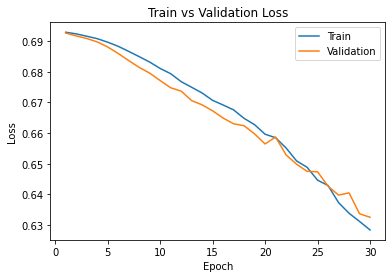

```python
large_net = LargeNet()
train_net(large_net, 512, 0.01, 30)
model_path_large = get_model_name("large", batch_size=512, learning_rate=0.01, epoch=29)
plot_training_curve(model_path_large)

# Train and validation error are close to converge. Train and validation loss are close to converge. The model do not have a overfitting problem anymore.
# The train loss continue to decrease till the end. It is a sign of underfit. The model can be further trained.
# The model is about 15 s faster. The increase of batch size decreased the run time.
# Increase in batch size allows the model to optimize the loss by having a bigger set of data.
```

### Part (d) - 3pt

Train `large_net` with all default parameters, including with `learning_rate=0.01`. Now, set `batch_size=16`. Does the model take longer/shorter to train? Plot the training curve. Describe the effect of *decreasing* the batch size.

```
Files already downloaded and verified
Files already downloaded and verified
Epoch 1: Train err: 0.432625, Train loss: 0.6775549505352974 |Validation err: 0.377, Validation loss: 0.6511285648345947
Epoch 2: Train err: 0.366, Train loss: 0.6392398532629013 |Validation err: 0.349, Validation loss: 0.6155489649772644
Epoch 3: Train err: 0.344, Train loss: 0.6131700966954231 |Validation err: 0.3355, Validation loss: 0.6260098805427551
Epoch 4: Train err: 0.3095, Train loss: 0.5831428338289261 |Validation err: 0.3455, Validation loss: 0.6068964569568635
Epoch 5: Train err: 0.30075, Train loss: 0.5661177406907082 |Validation err: 0.3105, Validation loss: 0.5775873973369599
Epoch 6: Train err: 0.286625, Train loss: 0.5434063944220543 |Validation err: 0.31, Validation loss: 0.5945679903030395
Epoch 7: Train err: 0.269875, Train loss: 0.5278522602915764 |Validation err: 0.2975, Validation loss: 0.5769600741863251
Epoch 8: Train err: 0.259875, Train loss: 0.5114860958456993 |Validation err: 0.306, Validation loss: 0.5818379497528077
Epoch 9: Train err: 0.2465, Train loss: 0.4917309710085392 |Validation err: 0.294, Validation loss: 0.5684631474018097
Epoch 10: Train err: 0.235875, Train loss: 0.4760364954173565 |Validation err: 0.3, Validation loss: 0.5880670266151429
Epoch 11: Train err: 0.224875, Train loss: 0.45866602374613286 |Validation err: 0.3055, Validation loss: 0.5975982645750045
Epoch 12: Train err: 0.201, Train loss: 0.43279091486334803 |Validation err: 0.302, Validation loss: 0.6265110239982605
Epoch 13: Train err: 0.20175, Train loss: 0.42180670572817325 |Validation err: 0.291, Validation loss: 0.6186187136173248
Epoch 14: Train err: 0.181375, Train loss: 0.3906784666925669 |Validation err: 0.288, Validation loss: 0.6491795233488082
Epoch 15: Train err: 0.16875, Train loss: 0.37004583737254143 |Validation err: 0.303, Validation loss: 0.7111082739830017
Epoch 16: Train err: 0.155, Train loss: 0.3471844617724419 |Validation err: 0.3085, Validation loss: 0.7596657290458679
Epoch 17: Train err: 0.150125, Train loss: 0.3336152036637068 |Validation err: 0.3095, Validation loss: 0.7119469507932663
Epoch 18: Train err: 0.13575, Train loss: 0.31507990255206825 |Validation err: 0.315, Validation loss: 0.8810964195728302
Epoch 19: Train err: 0.11625, Train loss: 0.28133674197643993 |Validation err: 0.3225, Validation loss: 0.8510603030920029
Epoch 20: Train err: 0.12575, Train loss: 0.2925715168043971 |Validation err: 0.3215, Validation loss: 0.8689135358333587
Epoch 21: Train err: 0.11675, Train loss: 0.2726807276792824 |Validation err: 0.3135, Validation loss: 0.8834547828435898
Epoch 22: Train err: 0.109, Train loss: 0.25579224648699167 |Validation err: 0.317, Validation loss: 0.9504440996646881
Epoch 23: Train err: 0.104125, Train loss: 0.250390624538064 |Validation err: 0.312, Validation loss: 0.9592446065545082
Epoch 24: Train err: 0.094875, Train loss: 0.23668015228025616 |Validation err: 0.3245, Validation loss: 0.9686237223148346
Epoch 25: Train err: 0.093375, Train loss: 0.22692184282280506 |Validation err: 0.316, Validation loss: 1.1366441640853882
Epoch 26: Train err: 0.086375, Train loss: 0.21100784596242012 |Validation err: 0.324, Validation loss: 1.1808369347453118
Epoch 27: Train err: 0.081625, Train loss: 0.20323290424607693 |Validation err: 0.3235, Validation loss: 1.2268096795082093
Epoch 28: Train err: 0.073125, Train loss: 0.18103269643709063 |Validation err: 0.3135, Validation loss: 1.1513856991529465
Epoch 29: Train err: 0.069875, Train loss: 0.1856807148111984 |Validation err: 0.3135, Validation loss: 1.2462449444532395
Epoch 30: Train err: 0.067625, Train loss: 0.17660465083643795 |Validation err: 0.323, Validation loss: 1.2343204513192176
Finished Training
Total time elapsed: 192.85 seconds
```

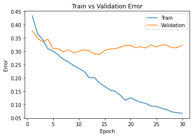

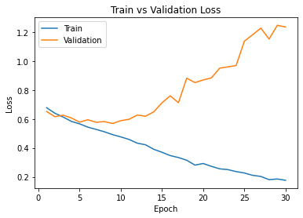

```python
large_net = LargeNet()
train_net(large_net, 16, 0.01, 30)
model_path_large = get_model_name("large", batch_size=16, learning_rate=0.01, epoch=29)
plot_training_curve(model_path_large)

# The result from a model with a learning_rate = 0.01, epoch = 29 and batch size = 16 is more than 60 s slower than the original model
# The decrease in the batch size increased the training time. Per epoch has more iterations/tests.
# The model has an overfitting issue. The model fits well for the train set and failed to fit the test set.
# The model needs to be adjusted since both loss and error failed to converge.
```

## Part 4. Hyperparameter Search [6 pt]

### Part (a) - 2pt

Based on the plots from above, choose another set of values for the hyperparameters (network, batch_size, learning_rate) that you think would help you improve the validation accuracy. Justify your choice.

```python
# For network, i choose larget network. It has more hidden layer.
# For batch size, i will choose 100. When the batch size is 16, it seems to have overfitting issue. When the batch size is 512, it seems to have a bit of underfitting issue.
# For learning rate, i will choose 0.01 since a learning rate of 0.1 caused overfitting issue.
# For epoch, i will use the default value.
```

### Part (b) - 1pt

Train the model with the hyperparameters you chose in part(a), and include the training curve.

```
Files already downloaded and verified
Files already downloaded and verified
Epoch 1: Train err: 0.449875, Train loss: 0.6916022531688213 |Validation err: 0.4305, Validation loss: 0.6880389422178268
Epoch 2: Train err: 0.437, Train loss: 0.6853248670697212 |Validation err: 0.4145, Validation loss: 0.6793564170598984
Epoch 3: Train err: 0.410375, Train loss: 0.6764710426330567 |Validation err: 0.4105, Validation loss: 0.6686394780874252
Epoch 4: Train err: 0.39725, Train loss: 0.6675531089305877 |Validation err: 0.39, Validation loss: 0.6598745256662368
Epoch 5: Train err: 0.3805, Train loss: 0.6568094931542874 |Validation err: 0.378, Validation loss: 0.6477478981018067
Epoch 6: Train err: 0.3575, Train loss: 0.6406385689973831 |Validation err: 0.3605, Validation loss: 0.6376440793275833
Epoch 7: Train err: 0.356375, Train loss: 0.6316433548927307 |Validation err: 0.356, Validation loss: 0.6279703378677368
Epoch 8: Train err: 0.34875, Train loss: 0.6212809532880783 |Validation err: 0.359, Validation loss: 0.628507113456726
Epoch 9: Train err: 0.334625, Train loss: 0.6088398836553097 |Validation err: 0.3225, Validation loss: 0.609757336974144
Epoch 10: Train err: 0.324125, Train loss: 0.5971007604151964 |Validation err: 0.333, Validation loss: 0.6085003584623336
Epoch 11: Train err: 0.31625, Train loss: 0.5901349738240242 |Validation err: 0.323, Validation loss: 0.603022626042366
Epoch 12: Train err: 0.304375, Train loss: 0.5757561758160591 |Validation err: 0.3215, Validation loss: 0.6000827893614769
Epoch 13: Train err: 0.300125, Train loss: 0.5694146506488323 |Validation err: 0.3145, Validation loss: 0.6000158488750458
Epoch 14: Train err: 0.293625, Train loss: 0.55885049700737 |Validation err: 0.3115, Validation loss: 0.5994103074073791
Epoch 15: Train err: 0.28225, Train loss: 0.5501508947461844 |Validation err: 0.323, Validation loss: 0.604857987165451
Epoch 16: Train err: 0.276625, Train loss: 0.5426745068281889 |Validation err: 0.3005, Validation loss: 0.5871532320976257
Epoch 17: Train err: 0.270125, Train loss: 0.5338211853057147 |Validation err: 0.2995, Validation loss: 0.5891825646162033
Epoch 18: Train err: 0.263625, Train loss: 0.5243716228753328 |Validation err: 0.3045, Validation loss: 0.5846922129392624
Epoch 19: Train err: 0.255625, Train loss: 0.5131407286971807 |Validation err: 0.305, Validation loss: 0.5811537504196167
Epoch 20: Train err: 0.2515, Train loss: 0.5068157337605953 |Validation err: 0.292, Validation loss: 0.5850128293037414
Epoch 21: Train err: 0.25475, Train loss: 0.5035317406058312 |Validation err: 0.301, Validation loss: 0.5841795086860657
Epoch 22: Train err: 0.2395, Train loss: 0.49320297949016095 |Validation err: 0.3265, Validation loss: 0.6048011392354965
Epoch 23: Train err: 0.242125, Train loss: 0.4903627406805754 |Validation err: 0.2995, Validation loss: 0.5837390899658204
Epoch 24: Train err: 0.23675, Train loss: 0.4825875464826822 |Validation err: 0.331, Validation loss: 0.6439174741506577
Epoch 25: Train err: 0.23075, Train loss: 0.473565037176013 |Validation err: 0.327, Validation loss: 0.6015979275107384
Epoch 26: Train err: 0.219375, Train loss: 0.45926870293915273 |Validation err: 0.317, Validation loss: 0.6031333103775978
Epoch 27: Train err: 0.22075, Train loss: 0.4610967800021172 |Validation err: 0.3025, Validation loss: 0.596827857196331
Epoch 28: Train err: 0.2155, Train loss: 0.45328850373625756 |Validation err: 0.2975, Validation loss: 0.6006372511386872
Epoch 29: Train err: 0.212, Train loss: 0.4471586041152477 |Validation err: 0.321, Validation loss: 0.6275491863489151
Epoch 30: Train err: 0.204375, Train loss: 0.4372466173022985 |Validation err: 0.296, Validation loss: 0.6083080261945725
Finished Training
Total time elapsed: 117.39 seconds
```

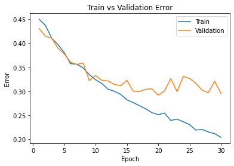

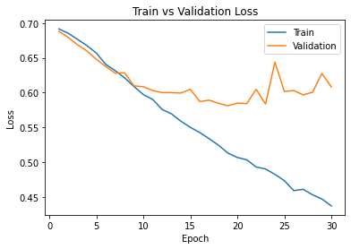

```python
large_net = LargeNet()
train_net(large_net, 100, 0.01, 30)
model_path_large = get_model_name("large", batch_size=100, learning_rate=0.01, epoch=29)
plot_training_curve(model_path_large)
```

### Part (c) - 2pt

Based on your result from Part(a), suggest another set of hyperparameter values to try. Justify your choice.

```python
# The above model seems to have a converging loss. The train error and validation error still have a small gap
# The model has an overfitting issue. The validation loss reduced then increased while the train error reduced.
# I will reduce the epoch to 25 and increase the batch size to 1000. Maybe a smaller # epoch can help the model to optimize the loss.
```

### Part (d) - 1pt

Train the model with the hyperparameters you chose in part(c), and include the training curve.

```
Files already downloaded and verified
Files already downloaded and verified
Epoch 1: Train err: 0.48675, Train loss: 0.6930271983146667 |Validation err: 0.4935, Validation loss: 0.693024754524231
Epoch 2: Train err: 0.475375, Train loss: 0.6928364336490631 |Validation err: 0.4705, Validation loss: 0.6926329731941223
Epoch 3: Train err: 0.4645, Train loss: 0.6925171986222267 |Validation err: 0.4495, Validation loss: 0.6922369599342346
Epoch 4: Train err: 0.452, Train loss: 0.6921849474310875 |Validation err: 0.432, Validation loss: 0.6918369829654694
Epoch 5: Train err: 0.44125, Train loss: 0.6918214112520218 |Validation err: 0.433, Validation loss: 0.6913796067237854
Epoch 6: Train err: 0.436375, Train loss: 0.6914336979389191 |Validation err: 0.427, Validation loss: 0.6908853054046631
Epoch 7: Train err: 0.44025, Train loss: 0.6910219267010689 |Validation err: 0.4215, Validation loss: 0.6903194487094879
Epoch 8: Train err: 0.441625, Train loss: 0.6905809789896011 |Validation err: 0.4295, Validation loss: 0.6896635890007019
Epoch 9: Train err: 0.440375, Train loss: 0.6900249719619751 |Validation err: 0.4235, Validation loss: 0.6889941692352295
Epoch 10: Train err: 0.435625, Train loss: 0.6894251257181168 |Validation err: 0.4195, Validation loss: 0.6882230341434479
Epoch 11: Train err: 0.435125, Train loss: 0.6887736767530441 |Validation err: 0.422, Validation loss: 0.6871142685413361
Epoch 12: Train err: 0.43575, Train loss: 0.6879348158836365 |Validation err: 0.425, Validation loss: 0.6860407590866089
Epoch 13: Train err: 0.436875, Train loss: 0.6871484741568565 |Validation err: 0.4255, Validation loss: 0.6848313808441162
Epoch 14: Train err: 0.434875, Train loss: 0.6862560957670212 |Validation err: 0.4195, Validation loss: 0.6836631298065186
Epoch 15: Train err: 0.431375, Train loss: 0.6853270009160042 |Validation err: 0.4175, Validation loss: 0.6824901401996613
Epoch 16: Train err: 0.430125, Train loss: 0.6843788549304008 |Validation err: 0.4135, Validation loss: 0.6814298331737518
Epoch 17: Train err: 0.427875, Train loss: 0.6834634691476822 |Validation err: 0.412, Validation loss: 0.6804192960262299
Epoch 18: Train err: 0.428, Train loss: 0.6824102103710175 |Validation err: 0.409, Validation loss: 0.6792144477367401
Epoch 19: Train err: 0.42575, Train loss: 0.6814889386296272 |Validation err: 0.4115, Validation loss: 0.6779310703277588
Epoch 20: Train err: 0.422875, Train loss: 0.6805325821042061 |Validation err: 0.414, Validation loss: 0.6771958470344543
Epoch 21: Train err: 0.421375, Train loss: 0.6793785616755486 |Validation err: 0.4125, Validation loss: 0.6759819388389587
Epoch 22: Train err: 0.41875, Train loss: 0.6784152761101723 |Validation err: 0.4105, Validation loss: 0.6747995913028717
Epoch 23: Train err: 0.416125, Train loss: 0.6772990524768829 |Validation err: 0.4145, Validation loss: 0.6739149987697601
Epoch 24: Train err: 0.412, Train loss: 0.6762191206216812 |Validation err: 0.413, Validation loss: 0.6728242039680481
Epoch 25: Train err: 0.411375, Train loss: 0.6752014681696892 |Validation err: 0.414, Validation loss: 0.6718256175518036
Finished Training
Total time elapsed: 100.28 seconds
```

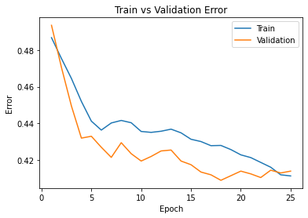

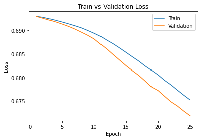

```python
large_net = LargeNet()
train_net(large_net, 1000, 0.01, 25)
model_path_large = get_model_name("large", batch_size=1000, learning_rate=0.01, epoch=24)
plot_training_curve(model_path_large)
```